# Comparison of VR Based and Traditional Treatments of Depression on Males and Females Aged 18-80 Ruth Campion Niall McHugh Ca1 DKIT 2024/2025

Here we have visualised the pre and post treatment scores by gender and group. It is interesting to observe that males tend to score lower and have less change, whereas females tend to score higher and also seem to experience a greater benefit from the treatment.

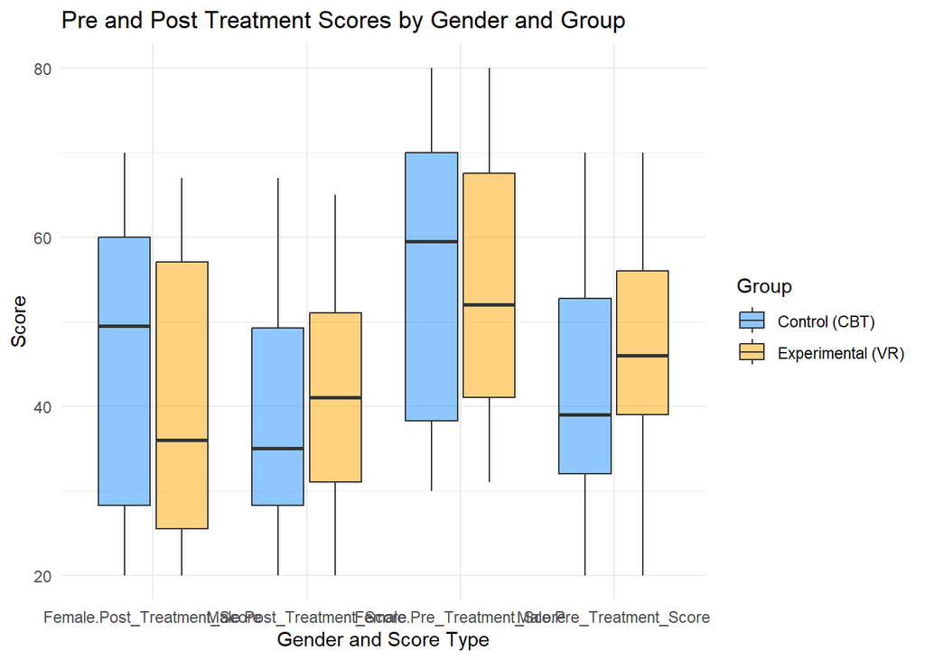

```r
# Change to Long Format
long_data <- depression_data %>%
  pivot_longer(
    cols = c(Pre_Treatment_Score, Post_Treatment_Score),
    names_to = "Score_Type",    # New column indicating "Pre" or "Post"
    values_to = "Score"         # Column for scores
  )

#BoxPlot
ggplot(long_data, aes(x = interaction(Gender, Score_Type), y = Score, fill = Group)) +
  geom_boxplot(alpha = 0.5) +
  labs(
    title = "Pre and Post Treatment Scores by Gender and Group",
    x = "Gender and Score Type",
    y = "Score",
    fill = "Group"
  ) +
  theme_minimal() +
  scale_x_discrete(labels = c("Male Pre" = "Male (Pre)", "Male Post" = "Male (Post)",
                              "Female Pre" = "Female (Pre)", "Female Post" = "Female (Post)"))+
  scale_fill_manual(values = c("dodgerblue1", "orange"))
```

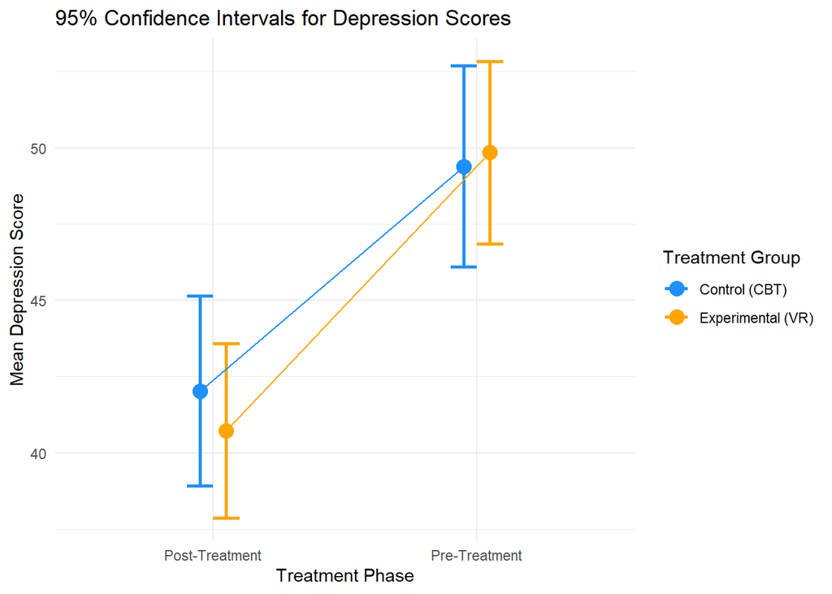

```r
#Pre Treatment Histogram
ggplot(summary_data, aes(x = Treatment_Phase, y = Mean_Score, color = Group, group = Group)) +
  geom_point(size = 4, position = position_dodge(0.2)) +  # Add points for means
  geom_errorbar(
    aes(ymin = Lower_CI, ymax = Upper_CI),
    width = 0.2, size = 1, position = position_dodge(0.2)
  ) +
  geom_line(position = position_dodge(0.2)) +  # Connect points with lines
  labs(
    title = "95% Confidence Intervals for Depression Scores",
    x = "Treatment Phase",
    y = "Mean Depression Score",
    color = "Treatment Group"
  ) +
  theme_minimal() +
  scale_color_manual(values = c("dodgerblue1", "orange")) +
  scale_x_discrete(labels = c("Pre_Treatment_Score" = "Pre-Treatment", "Post_Treatment_Score" = "Post-Treatment"))
```

**Discussion**

It would be interesting if the data on the specific age of the participants had been gathered, as this could be a influential factor when analysing the data. Had the effectiveness of the treatment been skewed in favour of an age group as well as a gender group this could have been something worth considering in our evaluation.

It would also have been useful to know whether the participants were receiving other forms of pharmaceutical or non-pharmaceutical therapy to treat their depression.

It would be good to know about the design of the VR aspect of the experimental treatment. Given that the quality of the VR experiment could effect the response to the sensory data in the participants (Sanches-Vives and Slater, 2005), it would be interesting to know by what principles this experiment was designed. Perhaps another experiment which compares different types of VR treatments would be a useful study.

**References**

UBC Emerging Media Lab (2021). *Immersion and Memory: How Our Brains Understand Virtual Worls*. [online] YouTube. Available at: https://www.youtube.com/watch?v=jH2UhC1HS_M [Accessed 5 Jan. 2025].

‌Sanchez-Vives, M.V. and Slater, M. (2005). From presence to consciousness through virtual reality. *Nature Reviews Neuroscience*, [online] 6(4), pp.332–339. doi:https://doi.org/10.1038/nrn1651.

‌